# Correspondence Analysis Presentation with R

### 8. Asymmetric Biplot

In accordance with the weakness of symmetric biplot which doesn't take into account column and rows to be interpreted in the same manner, there is assymetric biplot which used for interpreting distance between column points and row points. This approach should make sure that column profiles must be presented in row space or vice-versa.

To make an asymetric biplot, rows (or columns) points are plotted from the standard co-ordinates (S) and the profiles of the columns (or the rows) are plotted from the principale coordinates (P) (M. Bendixen 2003).

For a given axis, the standard and principle co-ordinates are related as follows:

P = sqrt(eigenvalue) X S

- P: the principal coordinate of a row (or a column) on the axis
- eigenvalue: the eigenvalue of the axis

Depending on the situation, other types of display can be set using the argument map (Nenadic and Greenacre 2007)

### 8a. Asymetric Biplot

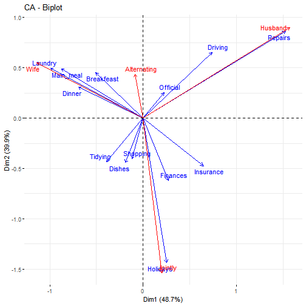

```r
fviz_ca_biplot(vis_ca,
               map ="rowprincipal", arrow=c(TRUE, TRUE),
               repel = TRUE)
```

This graph uses argument arrows, which is a vector of two logicals specifying if the plot should contain points or arrows. The first value sets the row and the second value sets the columns. The point to take here is if the **angle** between two arrows is acute, then there is a strong association between the corresponding row and columns. To interpret the distance between rows and columns, there is a need to perpendicularly project row points on the column arrow

### 9. Create Predictions

After taking the detail about symmetric and asymetric biplot, there has to be interest to utilize the CA model to predict data. Therefore, here is example of what type of data and prediction

In predicting the data, there is supplementary elements that represent the data we want to predict. Lets take a look.

Describing dataset:

Ref: https://search.r-project.org/CRAN/refmans/FactoMineR/html/children.html

### 9a. Inspect Dataset

```r
data(children)
head(children)
```

```
              unqualified cep bepc high_school_diploma university thirty fifty
money                  51  64   32                  29         17     59    66
future                 53  90   78                  75         22    115   117
unemployment           71 111   50                  40         11     79    88
circumstances           1   7    5                   5          4      9     8
hard                    7  11    4                   3          2      2    17
economic                7  13   12                  11         11     18    19
              more_fifty
money                 70
future                86
unemployment         177
circumstances          5
hard                  18
economic              17
```

In this dataset, there is a need to separate between active and supplementary for each column and row, this is to provide active as kinda training dataset and supplementary as test dataset. Here is the description for each part:

- Active rows (rows 1:14) : Rows that are used during the correspondence analysis.
- Supplementary rows (row.sup 15:18) : The coordinates of these rows will be predicted using the CA information and parameters obtained with active rows/columns
- Active columns (columns 1:5) : Columns that are used for the correspondence analysis.
- Supplementary columns (col.sup 6:8) : As supplementary rows, the coordinates of these columns will be predicted also.

### 9b. Specify supplementary rows and columns:

```r
viss_ca = CA(children, row.sup = 15:18, col.sup = 6:8,
             graph = FALSE)
```

```r
viss_ca
```

```
**Results of the Correspondence Analysis (CA)**
The row variable has  14  categories; the column variable has 5 categories
The chi square of independence between the two variables is equal to 98.80159 (p-value =  9.748064e-05 ).
*The results are available in the following objects:

   name              description
1  "$eig"            "eigenvalues"
2  "$col"            "results for the columns"
3  "$col$coord"      "coord. for the columns"
4  "$col$cos2"       "cos2 for the columns"
5  "$col$contrib"    "contributions of the columns"
6  "$row"            "results for the rows"
7  "$row$coord"      "coord. for the rows"
8  "$row$cos2"       "cos2 for the rows"
9  "$row$contrib"    "contributions of the rows"
10 "$row.sup$coord"  "coord. for supplementary rows"
11 "$row.sup$cos2"   "cos2 for supplementary rows"
12 "$col.sup$coord"  "coord. for supplementary columns"
13 "$col.sup$cos2"   "cos2 for supplementary columns"
14 "$call"           "summary called parameters"
15 "$call$marge.col" "weights of the columns"
16 "$call$marge.row" "weights of the rows"
```

- X : a data frame (contingency table)
- row.sup : a numeric vector specifying the indexes of the supplementary rows
- col.sup : a numeric vector specifying the indexes of the supplementary columns
- ncp : number of dimensions kept in the final results.
- graph : a logical value. If TRUE a graph is displayed.

### 9c. Symmetric Plot

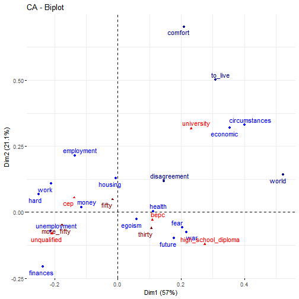

```r
fviz_ca_biplot(viss_ca, repel = TRUE)
```

This is symmetric biplot of the data, notice several diffrent sign and color:

- Active rows are in blue and supplementary rows are in dark blue
- Columns are in red and supplementary columns are in darkred

### Let see the predicted supplementary rows:

```r
viss_ca$row.sup
```

```
$coord
                 Dim 1     Dim 2      Dim 3      Dim 4
comfort      0.2096705 0.7031677 0.07111168  0.3071354
disagreement 0.1462777 0.1190106 0.17108916 -0.3132169
world        0.5233045 0.1429707 0.08399269 -0.1063597
to_live      0.3083067 0.5020193 0.52093397  0.2557357

$cos2
                  Dim 1      Dim 2       Dim 3      Dim 4
comfort      0.06892759 0.77524032 0.007928672 0.14790342
disagreement 0.13132177 0.08692632 0.179649183 0.60210272
world        0.87587685 0.06537746 0.022564054 0.03618163
to_live      0.13899699 0.36853645 0.396830367 0.09563620
```

### Plot of active and supplementary row points:

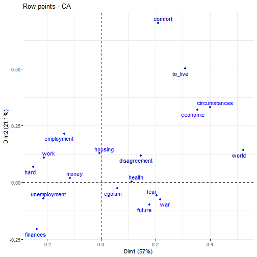

```r
fviz_ca_row(viss_ca, repel=TRUE)
```

### Lets see the predicted supplementary columns

```r
viss_ca$col.sup
```

```
$coord
                 Dim 1       Dim 2       Dim 3       Dim 4
thirty      0.10541339 -0.05969594 -0.10322613  0.06977996
fifty      -0.01706444  0.04907657 -0.01568923 -0.01306117
more_fifty -0.17706810 -0.04813788  0.10077299 -0.08517528

$cos2
               Dim 1      Dim 2       Dim 3       Dim 4
thirty     0.1375601 0.04411543 0.131910759 0.060278490
fifty      0.0108695 0.08990298 0.009188167 0.006367804
more_fifty 0.2860989 0.02114509 0.092666735 0.066200714
```

### Plot of active and supplementary columns:

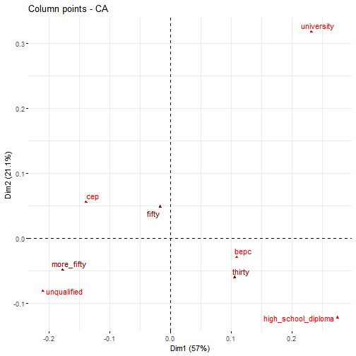

```r
fviz_ca_col(viss_ca, repel = TRUE)
```

In regards of showing graph, there is a way to filtering the result based on cos2 or contribution values, more on that in http://www.sthda.com/english/articles/31-principal-component-methods-in-r-practical-guide/113-ca-correspondence-analysis-in-r-essentials/

### 10. Deal with Outliers

if one or more “outliers” are present in the contigency table, they can dominate the interpretation the axes (M. Bendixen 2003). The outliers can be distinguished from the exceptionally high value of coordinates and contributions as seen in the graph that set far apart from the centroid. If this occur, the remaining columns or rows tend to be tightly clustered which make it difficult to interpret.

To detect outlier, the approach is to lookup for the coordinates of row/column points since it represent the standard deviation of row/column away from the barycentre (M. Bendixen 2003). In order to detect outliers, it usually appear at least one standard deviation away from the barycentre, they contribute also, significantly to the interpretation to one pole of an axis. If there's outlier, it has to be suppressed if used for creatinf CA, otherwise, use it as supplementary points.

### At the End

This mark the end of Correspondence Analysis with R, most of the material are taken from the reference that mentioned upfront, hope this explanation can be further described to eliminate the black box, thank you and happy learning! :)